# Curso I – SISSA

Ejercicio 1.2 - Resuelto

## Bienvenida/o

Bienvenida/o al primer ejercicio práctico del *Taller de fusión de datos satelitales con estaciones*. ¡Esperamos que esté listo para probar algunas cosas!

## Esquema

Este tutorial está compuesto por un ejercicio:

- ¿Cuánto llueve en las ciudades colombianas?

Después de completar este tutorial, podrás extraer información de conjuntos de datos ráster.

## ¿Cuánto llueve en las ciudades colombianas?

En la carpeta CHIRPS_monthly, tenemos rásters de precipitación mensual desde el 2000 hasta el 2003. Queremos analizar la diferencia en la precipitación mensual entre Bogotá (4.7, -74.1) y Medellín (6.2, -75.6). El shapefile de Colombia se encuentra en la carpeta Exercise_1/Part_2/Colombia.

1. Graficar las ubicaciones de las dos ciudades junto con el primer ráster de precipitación mensual, enmascarado para el área de Colombia.
2. Extraer la serie temporal de precipitación mensual para las dos ciudades.
3. Graficar las dos series temporales como un gráfico de línea.
4. Calcular las diferencias en la precipitación mensual entre las dos ciudades.

Primero, debemos cargar los paquetes que utilizaremos.

```r
library(terra)
library(sf)
```

A continuación, estableceremos las rutas a los datos.

```r
chirps_path   <- "C:/Users/Data/Part_2/CHIRPS_monthly"
colombia_path <- "C:/Users/Data/Part_2/Colombia/COL_adm0.shp"
```

Tenemos que leer el shapefile de Colombia y listar los archivos CHIRPS.

```r
colombia     <- vect(colombia_path)
chirps_files <- list.files(chirps_path, full.names = TRUE)
```

Veamos el shapefile:

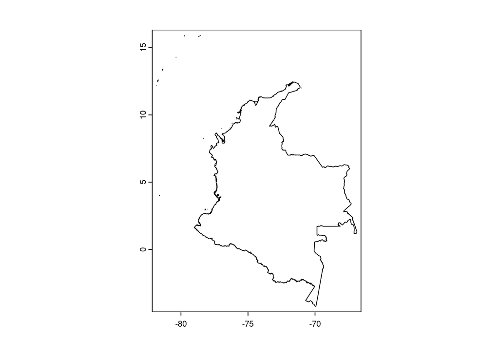

```r
plot(colombia, axes = TRUE)
```

Creamos un data frame con la ubicación de las ciudades y lo convertimos en un objeto espacial.

```r
cities <- data.frame(Name = c("Bogota", "Medellin"),
                     lon = c(-74.1, -75.6),
                     lat = c(4.7, 6.2))
cities <- st_as_sf(cities, coords = c("lon", "lat"))
cities <- vect(cities)
```

Ahora hacemos un *stack* de los archivos CHIRPS y los recortamos de acuerdo al área de estudio.

```r
chirps_stack <- rast(chirps_files)
chirps_stack <- crop(chirps_stack, colombia, snap = "OUT")
```

**Solución A**

Una vez que tenemos el *stack* de CHIRPS recortado deacuerdo a Colombia, podemos gueardar el primer archivo CHIRPS como un objeto y luego enmascararlo usando el shapefile del área de estudio.

```r
jan_2000 <- chirps_stack[[1]]
jan_2000 <- mask(jan_2000, colombia)
```

Ahora, podemos graficar el ráster junto con las ubicaciones de Bogotá y Medellín.

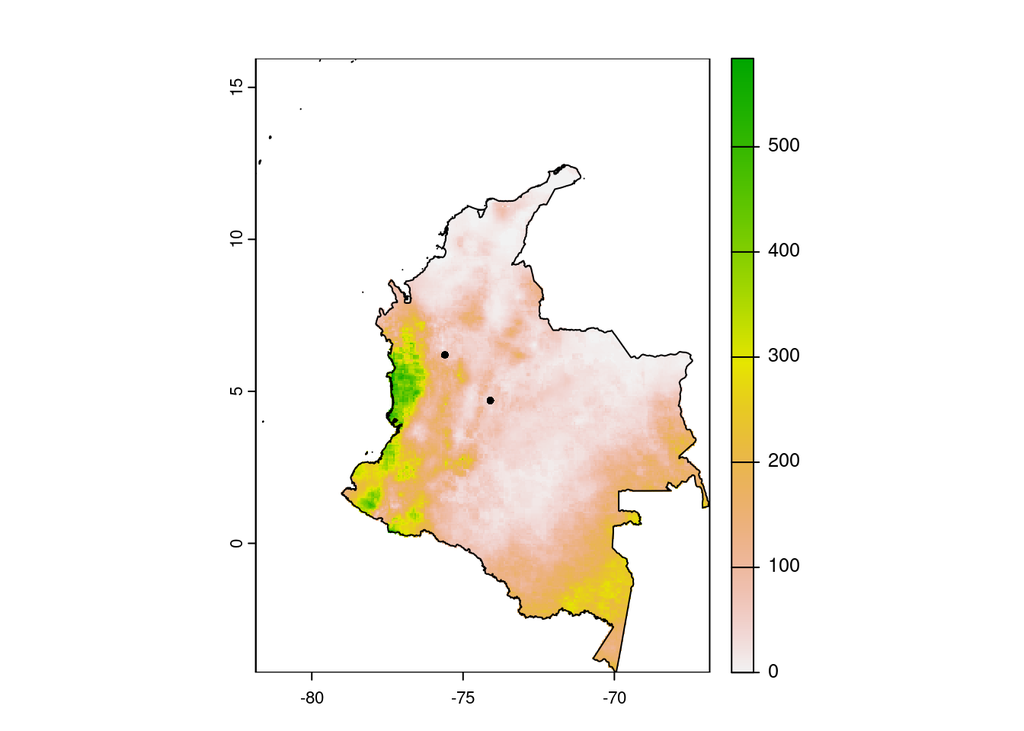

```r
plot(jan_2000)
lines(colombia)
points(cities)
```

**Solución B**

Usamos la función **extract** para obtener la serie temporal de ambas ciudades. Como resultado, obtendremos un data frame con 2 filas y 49 columnas. La primera fila contendrá los datos para Bogotá, mientras que la segunda contendrá los datos para Medellín.

```r
p_cities <- terra::extract(chirps_stack, cities)
dim(p_cities)
```

```
## [1]  2 49
```

```r
# Aquí, separamos los datos para ambas ciudades, excluyendo la primera columna (la del ID)
bogota_p   <- as.numeric(p_cities[1, -1 ])
medellin_p <- as.numeric(p_cities[2, -1 ])
print(bogota_p)
```

```
##  [1]  26.01648  43.87797  54.19332  53.78993  73.42372  58.97512  64.15267
##  [8]  52.20889  81.87256  72.41448  41.31596  23.27617  13.96754  24.57698
## [15]  52.80560  29.72800  77.57053  46.98207  38.77486  30.62109  61.37615
## [22]  58.45210  58.78082  43.50504  13.99164  13.99624  63.66564 119.72684
## [29]  84.95819  76.46921  39.07662  42.53190  43.68065  79.46979  31.62677
## [36]  38.64576  10.15345  22.97553  56.89735  94.54290  39.24740  62.44681
## [43]  43.23598  37.36733  47.66502 101.52205  82.42000  39.18044
```

```r
print(medellin_p)
```

```
##  [1]  80.65581 142.75757 145.17582 201.17267 272.66738 266.31411 199.57352
##  [8] 170.04138 284.45867 254.67384 131.80861 129.35348  85.39810  70.93958
## [15] 166.66690 126.14707 162.60637 118.08762 154.77400  40.00353 219.03648
## [22] 267.32960 174.36598 127.56710  44.92212  66.79132 138.17970 270.20089
## [29] 216.79399 143.26768  96.01857  87.06222 151.01849 269.41480 137.76650
## [36] 127.90530  22.06218 105.67618 129.25038 210.72907 190.70939 242.21506
## [43] 100.04607 182.19070 191.23021 289.52303 214.97617  95.93860
```

**Solución C**

Para graficar las dos series de tiempo como un gráfico de línea:

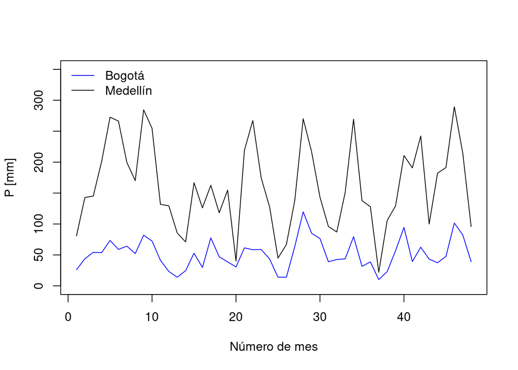

```r
plot(bogota_p, type = "l", col = "blue", ylim = c(0, 350),
     xlab = "Número de mes", ylab = "P [mm]")
lines(medellin_p, col = "black")
legend("topleft", c("Bogotá", "Medellín"), lty = 1, col = c("blue", "black"), bty = "n")
```

**Solución D**

Para calcular las diferencias en la precipitación mensual entre las dos ciudades, primero crearemos un vector con las fechas.

```r
dates <- substr(names(chirps_stack), 15, 21)
```

Podemos crear un data frame resumen con las fechas y las series de tiempo de precipitación para ambas ciudades.

```r
p_summary <- data.frame(Dates = dates, Bogota = bogota_p, Medellin = medellin_p)
head(p_summary)
```

```
##     Dates   Bogota  Medellin
## 1 2000-01 26.01648  80.65581
## 2 2000-02 43.87797 142.75757
## 3 2000-03 54.19332 145.17582
## 4 2000-04 53.78993 201.17267
## 5 2000-05 73.42372 272.66738
## 6 2000-06 58.97512 266.31411
```

Ahora, calcularemos la diferencia en la precipitación mensual entre las dos ciudades.

```r
p_summary$Difference <- p_summary$Medellin - p_summary$Bogota
head(p_summary)
```

```
##     Dates   Bogota  Medellin Difference
## 1 2000-01 26.01648  80.65581   54.63933
## 2 2000-02 43.87797 142.75757   98.87960
## 3 2000-03 54.19332 145.17582   90.98249
## 4 2000-04 53.78993 201.17267  147.38274
## 5 2000-05 73.42372 272.66738  199.24367
## 6 2000-06 58.97512 266.31411  207.33899
```